# Regression Learning

- Data preprocessing
- Regression Algorithms
- Feature Selection
- Hyperparametetr optimization

The dataset is about Air Pollution in Skopje - Center - Macedonia

The goal is to predict the PM10 concentration using the weather-meteorological data

The features are explained in Data_Info (some of them are removed)

```python
import matplotlib.pyplot as plt
import numpy as np
import pandas as pd
import seaborn as sns
%matplotlib inline
```

## 1. Load the Data

```python
data = pd.read_csv('Centar_ready_reduced.csv')
# visualize the data
data
```

|  | time | PM10 | apparentTemperature | cloudCover | dewPoint | humidity | precipIntensity | precipProbability | pressure | temperature | ... | no precip | rain | sleet | snow | Clear | Drizzle | Foggy | Mostly Cloudy | Overcast | Partly Cloudy |
| --- | --- | --- | --- | --- | --- | --- | --- | --- | --- | --- | --- | --- | --- | --- | --- | --- | --- | --- | --- | --- | --- |
| 0 | 1/1/15 0:00 | 30.020000 | 9.03 | 0.44 | 5.03 | 0.58 | 0.0 | 0.0 | 1033.580000 | 17.41 | ... | 1 | 0 | 0 | 0 | 0 | 0 | 0 | 0 | 0 | 1 |
| 1 | 1/1/15 1:00 | 30.210000 | 4.87 | 0.44 | 3.24 | 0.57 | 0.0 | 0.0 | 1033.860000 | 15.63 | ... | 1 | 0 | 0 | 0 | 0 | 0 | 0 | 0 | 0 | 1 |
| 2 | 1/1/15 2:00 | 29.400000 | 3.62 | 0.44 | 3.24 | 0.62 | 0.0 | 0.0 | 1034.140000 | 13.80 | ... | 1 | 0 | 0 | 0 | 0 | 0 | 0 | 0 | 0 | 1 |
| 3 | 1/1/15 3:00 | 28.830000 | 5.83 | 0.44 | 3.24 | 0.57 | 0.0 | 0.0 | 1034.420000 | 15.63 | ... | 1 | 0 | 0 | 0 | 0 | 0 | 0 | 0 | 0 | 1 |
| 4 | 1/1/15 4:00 | 27.690000 | 5.62 | 0.44 | 2.61 | 0.60 | 0.0 | 0.0 | 1034.990000 | 14.03 | ... | 1 | 0 | 0 | 0 | 0 | 0 | 0 | 0 | 0 | 1 |
| 5 | 1/1/15 5:00 | 27.280000 | 2.59 | 0.44 | 1.40 | 0.62 | 0.0 | 0.0 | 1035.560000 | 11.99 | ... | 1 | 0 | 0 | 0 | 0 | 0 | 0 | 0 | 0 | 1 |
| 6 | 1/1/15 6:00 | 26.040000 | 6.01 | 0.44 | 1.40 | 0.62 | 0.0 | 0.0 | 1036.130000 | 11.99 | ... | 1 | 0 | 0 | 0 | 0 | 0 | 0 | 0 | 0 | 1 |
| 7 | 1/1/15 7:00 | 25.770000 | 0.43 | 0.00 | 1.40 | 0.62 | 0.0 | 0.0 | 1036.213333 | 11.99 | ... | 1 | 0 | 0 | 0 | 1 | 0 | 0 | 0 | 0 | 0 |
| 8 | 1/1/15 8:00 | 24.470000 | 4.87 | 0.00 | 3.24 | 0.57 | 0.0 | 0.0 | 1036.296667 | 15.63 | ... | 1 | 0 | 0 | 0 | 1 | 0 | 0 | 0 | 0 | 0 |
| 9 | 1/1/15 9:00 | 21.940000 | 8.92 | 0.00 | 6.27 | 0.57 | 0.0 | 0.0 | 1036.380000 | 19.12 | ... | 1 | 0 | 0 | 0 | 1 | 0 | 0 | 0 | 0 | 0 |
| 10 | 1/1/15 10:00 | 20.630000 | 11.77 | 0.00 | 7.85 | 0.55 | 0.0 | 0.0 | 1035.626667 | 21.67 | ... | 1 | 0 | 0 | 0 | 1 | 0 | 0 | 0 | 0 | 0 |
| 11 | 1/1/15 11:00 | 19.440000 | 17.37 | 0.00 | 7.85 | 0.48 | 0.0 | 0.0 | 1034.873333 | 24.67 | ... | 1 | 0 | 0 | 0 | 1 | 0 | 0 | 0 | 0 | 0 |
| 12 | 1/1/15 12:00 | 20.620000 | 18.82 | 0.00 | 7.85 | 0.46 | 0.0 | 0.0 | 1034.120000 | 26.04 | ... | 1 | 0 | 0 | 0 | 1 | 0 | 0 | 0 | 0 | 0 |
| 13 | 1/1/15 13:00 | 22.520000 | 16.02 | 0.00 | 8.89 | 0.51 | 0.0 | 0.0 | 1034.420000 | 24.67 | ... | 1 | 0 | 0 | 0 | 1 | 0 | 0 | 0 | 0 | 0 |
| 14 | 1/1/15 14:00 | 24.350000 | 13.46 | 0.00 | 10.52 | 0.58 | 0.0 | 0.0 | 1034.720000 | 23.05 | ... | 1 | 0 | 0 | 0 | 1 | 0 | 0 | 0 | 0 | 0 |
| 15 | 1/1/15 15:00 | 26.720000 | 10.90 | 0.00 | 8.45 | 0.58 | 0.0 | 0.0 | 1035.020000 | 20.96 | ... | 1 | 0 | 0 | 0 | 1 | 0 | 0 | 0 | 0 | 0 |
| 16 | 1/1/15 16:00 | 31.170000 | 6.93 | 0.00 | 7.09 | 0.58 | 0.0 | 0.0 | 1035.620000 | 19.36 | ... | 1 | 0 | 0 | 0 | 1 | 0 | 0 | 0 | 0 | 0 |
| 17 | 1/1/15 17:00 | 32.080000 | 5.71 | 0.00 | 7.25 | 0.63 | 0.0 | 0.0 | 1036.220000 | 17.77 | ... | 1 | 0 | 0 | 0 | 1 | 0 | 0 | 0 | 0 | 0 |
| 18 | 1/1/15 18:00 | 30.530000 | 2.49 | 0.00 | 6.01 | 0.63 | 0.0 | 0.0 | 1036.820000 | 16.37 | ... | 1 | 0 | 0 | 0 | 1 | 0 | 0 | 0 | 0 | 0 |
| 19 | 1/1/15 19:00 | 39.520000 | 3.14 | 0.00 | 5.77 | 0.63 | 0.0 | 0.0 | 1037.180000 | 16.13 | ... | 1 | 0 | 0 | 0 | 1 | 0 | 0 | 0 | 0 | 0 |
| 20 | 1/1/15 20:00 | 58.960000 | 3.36 | 0.00 | 5.73 | 0.64 | 0.0 | 0.0 | 1037.540000 | 15.88 | ... | 1 | 0 | 0 | 0 | 1 | 0 | 0 | 0 | 0 | 0 |
| 21 | 1/1/15 21:00 | 60.740000 | 3.64 | 0.00 | 5.51 | 0.64 | 0.0 | 0.0 | 1037.900000 | 15.65 | ... | 1 | 0 | 0 | 0 | 1 | 0 | 0 | 0 | 0 | 0 |
| 22 | 1/1/15 22:00 | 69.430000 | 1.39 | 0.00 | 4.02 | 0.72 | 0.0 | 0.0 | 1038.073333 | 11.27 | ... | 1 | 0 | 0 | 0 | 1 | 0 | 0 | 0 | 0 | 0 |
| 23 | 1/1/15 23:00 | 106.190000 | 8.34 | 0.00 | 2.47 | 0.76 | 0.0 | 0.0 | 1038.246667 | 8.34 | ... | 1 | 0 | 0 | 0 | 1 | 0 | 0 | 0 | 0 | 0 |
| 24 | 1/2/15 0:00 | 142.950000 | 8.34 | 0.00 | 2.47 | 0.76 | 0.0 | 0.0 | 1038.420000 | 8.34 | ... | 1 | 0 | 0 | 0 | 1 | 0 | 0 | 0 | 0 | 0 |
| 25 | 1/2/15 1:00 | 124.150000 | 6.58 | 0.19 | 3.24 | 0.86 | 0.0 | 0.0 | 1038.290000 | 6.58 | ... | 1 | 0 | 0 | 0 | 0 | 0 | 0 | 0 | 0 | 1 |
| 26 | 1/2/15 2:00 | 117.240000 | 6.58 | 0.19 | 3.24 | 0.86 | 0.0 | 0.0 | 1038.160000 | 6.58 | ... | 1 | 0 | 0 | 0 | 0 | 0 | 0 | 0 | 0 | 1 |
| 27 | 1/2/15 3:00 | 107.990000 | 4.83 | 0.19 | -0.38 | 0.79 | 0.0 | 0.0 | 1038.030000 | 4.83 | ... | 1 | 0 | 0 | 0 | 0 | 0 | 0 | 0 | 0 | 1 |
| 28 | 1/2/15 4:00 | 120.140000 | 4.83 | 0.19 | -0.38 | 0.79 | 0.0 | 0.0 | 1037.828333 | 4.83 | ... | 1 | 0 | 0 | 0 | 0 | 0 | 0 | 0 | 0 | 1 |
| 29 | 1/2/15 5:00 | 191.260000 | 4.84 | 0.19 | -0.38 | 0.78 | NaN | NaN | 1037.626667 | 4.84 | ... | 0 | 0 | 0 | 1 | 0 | 0 | 0 | 0 | 0 | 1 |
| ... | ... | ... | ... | ... | ... | ... | ... | ... | ... | ... | ... | ... | ... | ... | ... | ... | ... | ... | ... | ... | ... |
| 8730 | 12/30/15 18:00 | 17.020000 | 27.33 | 0.74 | 22.05 | 0.61 | 0.0 | 0.0 | 1032.770000 | 34.07 | ... | 1 | 0 | 0 | 0 | 0 | 0 | 0 | 1 | 0 | 0 |
| 8731 | 12/30/15 19:00 | NaN | 29.01 | 0.75 | 22.15 | 0.64 | 0.0 | 0.0 | 1033.033333 | 33.20 | ... | 1 | 0 | 0 | 0 | 0 | 0 | 0 | 1 | 0 | 0 |
| 8732 | 12/30/15 20:00 | 16.920000 | 24.38 | 0.75 | 21.91 | 0.67 | 0.0 | 0.0 | 1033.296667 | 31.55 | ... | 1 | 0 | 0 | 0 | 0 | 0 | 0 | 1 | 0 | 0 |
| 8733 | 12/30/15 21:00 | 16.710000 | 24.49 | 0.48 | 20.91 | 0.66 | 0.0 | 0.0 | 1033.560000 | 30.95 | ... | 1 | 0 | 0 | 0 | 0 | 0 | 0 | 0 | 0 | 1 |
| 8734 | 12/30/15 22:00 | 17.070000 | 29.97 | 0.19 | 20.23 | 0.67 | 0.0 | 0.0 | 1033.680000 | 29.97 | ... | 1 | 0 | 0 | 0 | 0 | 0 | 0 | 0 | 0 | 1 |
| 8735 | 12/30/15 23:00 | 21.790000 | 28.13 | 0.19 | 19.70 | 0.70 | 0.0 | 0.0 | 1033.800000 | 28.13 | ... | 1 | 0 | 0 | 0 | 0 | 0 | 0 | 0 | 0 | 1 |
| 8736 | 12/31/15 0:00 | 26.510000 | 20.92 | 0.50 | 19.39 | 0.66 | 0.0 | 0.0 | 1033.920000 | 29.26 | ... | 1 | 0 | 0 | 0 | 0 | 0 | 0 | 1 | 0 | 0 |
| 8737 | 12/31/15 1:00 | 23.515000 | 20.42 | 0.19 | 17.61 | 0.74 | 0.0 | 0.0 | 1033.916667 | 24.62 | ... | 1 | 0 | 0 | 0 | 0 | 0 | 0 | 0 | 0 | 1 |
| 8738 | 12/31/15 2:00 | 20.520000 | 20.42 | 0.44 | 17.61 | 0.74 | 0.0 | 0.0 | 1033.913333 | 24.62 | ... | 1 | 0 | 0 | 0 | 0 | 0 | 0 | 0 | 0 | 1 |
| 8739 | 12/31/15 3:00 | 21.580000 | 18.61 | 0.40 | 18.05 | 0.76 | 0.0 | 0.0 | 1033.910000 | 24.61 | ... | 1 | 0 | 0 | 0 | 0 | 0 | 0 | 0 | 0 | 1 |
| 8740 | 12/31/15 4:00 | 18.170000 | 24.62 | 0.44 | 12.19 | 0.59 | 0.0 | 0.0 | 1034.080000 | 24.62 | ... | 1 | 0 | 0 | 0 | 0 | 0 | 0 | 0 | 0 | 1 |
| 8741 | 12/31/15 5:00 | 29.890000 | 9.28 | 0.19 | 14.00 | 0.74 | 0.0 | 0.0 | 1034.250000 | 21.01 | ... | 1 | 0 | 0 | 0 | 0 | 0 | 0 | 0 | 0 | 1 |
| 8742 | 12/31/15 6:00 | 35.150000 | 13.60 | 0.27 | 14.83 | 0.71 | 0.0 | 0.0 | 1034.420000 | 22.81 | ... | 1 | 0 | 0 | 0 | 0 | 0 | 0 | 0 | 0 | 1 |
| 8743 | 12/31/15 7:00 | 26.880000 | 21.01 | 0.19 | 14.00 | 0.74 | 0.0 | 0.0 | 1034.633333 | 21.01 | ... | 1 | 0 | 0 | 0 | 0 | 0 | 0 | 0 | 0 | 1 |
| 8744 | 12/31/15 8:00 | 24.920000 | 18.86 | 0.19 | 10.41 | 0.47 | 0.0 | 0.0 | 1034.846667 | 28.21 | ... | 1 | 0 | 0 | 0 | 0 | 0 | 0 | 0 | 0 | 1 |
| 8745 | 12/31/15 9:00 | 21.910000 | 22.47 | 0.24 | 10.11 | 0.45 | 0.0 | 0.0 | 1035.060000 | 28.72 | ... | 1 | 0 | 0 | 0 | 0 | 0 | 0 | 0 | 0 | 1 |
| 8746 | 12/31/15 10:00 | 21.600000 | 22.35 | 0.19 | 6.78 | 0.37 | 0.0 | 0.0 | 1034.146667 | 29.97 | ... | 1 | 0 | 0 | 0 | 0 | 0 | 0 | 0 | 0 | 1 |
| 8747 | 12/31/15 11:00 | NaN | 23.10 | 0.19 | 6.78 | 0.37 | 0.0 | 0.0 | 1033.233333 | 29.97 | ... | 1 | 0 | 0 | 0 | 0 | 0 | 0 | 0 | 0 | 1 |
| 8748 | 12/31/15 12:00 | NaN | 26.68 | 0.13 | 10.57 | 0.40 | 0.0 | 0.0 | 1032.320000 | 32.04 | ... | 1 | 0 | 0 | 0 | 0 | 0 | 0 | 0 | 0 | 1 |
| 8749 | 12/31/15 13:00 | 20.670000 | 28.63 | 0.00 | 6.78 | 0.34 | 0.0 | 0.0 | 1032.243333 | 31.82 | ... | 1 | 0 | 0 | 0 | 1 | 0 | 0 | 0 | 0 | 0 |
| 8750 | 12/31/15 14:00 | 17.960000 | 23.94 | 0.00 | 5.03 | 0.32 | 0.0 | 0.0 | 1032.166667 | 31.82 | ... | 1 | 0 | 0 | 0 | 1 | 0 | 0 | 0 | 0 | 0 |
| 8751 | 12/31/15 15:00 | 20.110000 | 23.17 | 0.13 | 7.82 | 0.38 | 0.0 | 0.0 | 1032.090000 | 30.20 | ... | 1 | 0 | 0 | 0 | 0 | 0 | 0 | 0 | 0 | 1 |
| 8752 | 12/31/15 16:00 | 41.830000 | 19.74 | 0.00 | 6.78 | 0.43 | 0.0 | 0.0 | 1032.386667 | 26.42 | ... | 1 | 0 | 0 | 0 | 1 | 0 | 0 | 0 | 0 | 0 |
| 8753 | 12/31/15 17:00 | 41.870000 | 15.83 | 0.00 | 10.41 | 0.54 | 0.0 | 0.0 | 1032.683333 | 24.62 | ... | 1 | 0 | 0 | 0 | 1 | 0 | 0 | 0 | 0 | 0 |
| 8754 | 12/31/15 18:00 | 53.760000 | 17.08 | 0.00 | 9.13 | 0.50 | 0.0 | 0.0 | 1032.980000 | 25.19 | ... | 1 | 0 | 0 | 0 | 1 | 0 | 0 | 0 | 0 | 0 |
| 8755 | 12/31/15 19:00 | 51.040000 | 19.62 | 0.00 | 10.90 | 0.56 | 0.0 | 0.0 | 1033.170000 | 24.19 | ... | 1 | 0 | 0 | 0 | 1 | 0 | 0 | 0 | 0 | 0 |
| 8756 | 12/31/15 20:00 | 59.000000 | 12.41 | 0.00 | 10.41 | 0.68 | 0.0 | 0.0 | 1033.360000 | 19.20 | ... | 1 | 0 | 0 | 0 | 1 | 0 | 0 | 0 | 0 | 0 |
| 8757 | 12/31/15 21:00 | 72.295000 | 13.36 | 0.00 | 8.82 | 0.58 | 0.0 | 0.0 | 1033.550000 | 21.45 | ... | 1 | 0 | 0 | 0 | 1 | 0 | 0 | 0 | 0 | 0 |
| 8758 | 12/31/15 22:00 | 85.590000 | 15.63 | 0.00 | 10.41 | 0.79 | 0.0 | 0.0 | 1033.416667 | 15.63 | ... | 1 | 0 | 0 | 0 | 1 | 0 | 0 | 0 | 0 | 0 |
| 8759 | 12/31/15 23:00 | 85.571815 | 13.80 | 0.00 | 8.58 | 0.79 | 0.0 | 0.0 | 1033.283333 | 13.80 | ... | 1 | 0 | 0 | 0 | 1 | 0 | 0 | 0 | 0 | 0 |

8760 rows × 25 columns

```python
# data statistics
data.describe()
```

|  | PM10 | apparentTemperature | cloudCover | dewPoint | humidity | precipIntensity | precipProbability | pressure | temperature | uvIndex | ... | no precip | rain | sleet | snow | Clear | Drizzle | Foggy | Mostly Cloudy | Overcast | Partly Cloudy |
| --- | --- | --- | --- | --- | --- | --- | --- | --- | --- | --- | --- | --- | --- | --- | --- | --- | --- | --- | --- | --- | --- |
| count | 7352.000000 | 8759.000000 | 8760.000000 | 8759.000000 | 8759.000000 | 8737.000000 | 8737.000000 | 8618.000000 | 8759.000000 | 7592.000000 | ... | 8760.000000 | 8760.000000 | 8760.0 | 8760.000000 | 8760.000000 | 8760.0 | 8760.000000 | 8760.000000 | 8760.000000 | 8760.000000 |
| mean | 72.802447 | 55.270738 | 0.434668 | 43.053717 | 0.665269 | 0.000174 | 0.004478 | 1018.756200 | 55.927233 | 0.981033 | ... | 0.978881 | 0.020776 | 0.0 | 0.000342 | 0.309703 | 0.0 | 0.042009 | 0.200114 | 0.176712 | 0.270434 |
| std | 82.213323 | 19.135721 | 0.387681 | 12.707508 | 0.204420 | 0.001894 | 0.032476 | 8.263537 | 18.350654 | 1.895410 | ... | 0.143788 | 0.142643 | 0.0 | 0.018504 | 0.462398 | 0.0 | 0.200621 | 0.400108 | 0.381447 | 0.444209 |
| min | 0.270000 | 0.430000 | 0.000000 | -2.210000 | 0.130000 | 0.000000 | 0.000000 | 986.110000 | 4.830000 | 0.000000 | ... | 0.000000 | 0.000000 | 0.0 | 0.000000 | 0.000000 | 0.0 | 0.000000 | 0.000000 | 0.000000 | 0.000000 |
| 25% | 27.627500 | 39.400000 | 0.000000 | 33.580000 | 0.520000 | 0.000000 | 0.000000 | 1013.137500 | 40.800000 | 0.000000 | ... | 1.000000 | 0.000000 | 0.0 | 0.000000 | 0.000000 | 0.0 | 0.000000 | 0.000000 | 0.000000 | 0.000000 |
| 50% | 42.680000 | 55.780000 | 0.440000 | 44.390000 | 0.700000 | 0.000000 | 0.000000 | 1017.860000 | 55.780000 | 0.000000 | ... | 1.000000 | 0.000000 | 0.0 | 0.000000 | 0.000000 | 0.0 | 0.000000 | 0.000000 | 0.000000 | 0.000000 |
| 75% | 77.680000 | 69.180000 | 0.750000 | 54.050000 | 0.830000 | 0.000000 | 0.000000 | 1023.550833 | 69.180000 | 1.000000 | ... | 1.000000 | 0.000000 | 0.0 | 0.000000 | 1.000000 | 0.0 | 0.000000 | 0.000000 | 0.000000 | 1.000000 |
| max | 815.170000 | 104.870000 | 1.000000 | 69.810000 | 1.000000 | 0.097200 | 0.240000 | 1041.920000 | 103.810000 | 9.000000 | ... | 1.000000 | 1.000000 | 0.0 | 1.000000 | 1.000000 | 0.0 | 1.000000 | 1.000000 | 1.000000 | 1.000000 |

8 rows × 24 columns

```python
# get the target variable... create X and y
# remove the rows with nan values in y
data.dropna(subset = ["PM10"], inplace=True)
y = pd.DataFrame(data.iloc[:,1])
X = data.drop(['time', 'PM10', 'sleet','Drizzle'], axis=1)
```

```python
X
```

|  | apparentTemperature | cloudCover | dewPoint | humidity | precipIntensity | precipProbability | pressure | temperature | uvIndex | visibility | ... | windGust | windSpeed | no precip | rain | snow | Clear | Foggy | Mostly Cloudy | Overcast | Partly Cloudy |
| --- | --- | --- | --- | --- | --- | --- | --- | --- | --- | --- | --- | --- | --- | --- | --- | --- | --- | --- | --- | --- | --- |
| 0 | 9.03 | 0.44 | 5.03 | 0.58 | 0.0 | 0.0 | 1033.580000 | 17.41 | 0.0 | 6.216 | ... | NaN | 5.82 | 1 | 0 | 0 | 0 | 0 | 0 | 0 | 1 |
| 1 | 4.87 | 0.44 | 3.24 | 0.57 | 0.0 | 0.0 | 1033.860000 | 15.63 | 0.0 | 6.216 | ... | NaN | 8.05 | 1 | 0 | 0 | 0 | 0 | 0 | 0 | 1 |
| 2 | 3.62 | 0.44 | 3.24 | 0.62 | 0.0 | 0.0 | 1034.140000 | 13.80 | 0.0 | 6.216 | ... | NaN | 6.93 | 1 | 0 | 0 | 0 | 0 | 0 | 0 | 1 |
| 3 | 5.83 | 0.44 | 3.24 | 0.57 | 0.0 | 0.0 | 1034.420000 | 15.63 | 0.0 | 6.216 | ... | NaN | 6.93 | 1 | 0 | 0 | 0 | 0 | 0 | 0 | 1 |
| 4 | 5.62 | 0.44 | 2.61 | 0.60 | 0.0 | 0.0 | 1034.990000 | 14.03 | 0.0 | 6.216 | ... | 5.29 | 5.29 | 1 | 0 | 0 | 0 | 0 | 0 | 0 | 1 |
| 5 | 2.59 | 0.44 | 1.40 | 0.62 | 0.0 | 0.0 | 1035.560000 | 11.99 | 0.0 | 6.216 | ... | NaN | 5.82 | 1 | 0 | 0 | 0 | 0 | 0 | 0 | 1 |
| 6 | 6.01 | 0.44 | 1.40 | 0.62 | 0.0 | 0.0 | 1036.130000 | 11.99 | 0.0 | 6.216 | ... | NaN | 3.36 | 1 | 0 | 0 | 0 | 0 | 0 | 0 | 1 |
| 7 | 0.43 | 0.00 | 1.40 | 0.62 | 0.0 | 0.0 | 1036.213333 | 11.99 | NaN | 6.216 | ... | NaN | 8.05 | 1 | 0 | 0 | 1 | 0 | 0 | 0 | 0 |
| 8 | 4.87 | 0.00 | 3.24 | 0.57 | 0.0 | 0.0 | 1036.296667 | 15.63 | NaN | 6.216 | ... | NaN | 8.05 | 1 | 0 | 0 | 1 | 0 | 0 | 0 | 0 |
| 9 | 8.92 | 0.00 | 6.27 | 0.57 | 0.0 | 0.0 | 1036.380000 | 19.12 | NaN | 6.216 | ... | 8.33 | 8.33 | 1 | 0 | 0 | 1 | 0 | 0 | 0 | 0 |
| 10 | 11.77 | 0.00 | 7.85 | 0.55 | 0.0 | 0.0 | 1035.626667 | 21.67 | NaN | 6.216 | ... | 8.69 | 8.69 | 1 | 0 | 0 | 1 | 0 | 0 | 0 | 0 |
| 11 | 17.37 | 0.00 | 7.85 | 0.48 | 0.0 | 0.0 | 1034.873333 | 24.67 | NaN | 6.216 | ... | 6.14 | 6.14 | 1 | 0 | 0 | 1 | 0 | 0 | 0 | 0 |
| 12 | 18.82 | 0.00 | 7.85 | 0.46 | 0.0 | 0.0 | 1034.120000 | 26.04 | NaN | 6.216 | ... | 6.38 | 6.38 | 1 | 0 | 0 | 1 | 0 | 0 | 0 | 0 |
| 13 | 16.02 | 0.00 | 8.89 | 0.51 | 0.0 | 0.0 | 1034.420000 | 24.67 | NaN | 6.216 | ... | 7.85 | 7.85 | 1 | 0 | 0 | 1 | 0 | 0 | 0 | 0 |
| 14 | 13.46 | 0.00 | 10.52 | 0.58 | 0.0 | 0.0 | 1034.720000 | 23.05 | NaN | 6.216 | ... | 8.69 | 8.69 | 1 | 0 | 0 | 1 | 0 | 0 | 0 | 0 |
| 15 | 10.90 | 0.00 | 8.45 | 0.58 | 0.0 | 0.0 | 1035.020000 | 20.96 | NaN | 6.216 | ... | 8.69 | 8.69 | 1 | 0 | 0 | 1 | 0 | 0 | 0 | 0 |
| 16 | 6.93 | 0.00 | 7.09 | 0.58 | 0.0 | 0.0 | 1035.620000 | 19.36 | 0.0 | 6.216 | ... | 11.92 | 11.92 | 1 | 0 | 0 | 1 | 0 | 0 | 0 | 0 |
| 17 | 5.71 | 0.00 | 7.25 | 0.63 | 0.0 | 0.0 | 1036.220000 | 17.77 | 0.0 | 6.216 | ... | 10.59 | 10.59 | 1 | 0 | 0 | 1 | 0 | 0 | 0 | 0 |
| 18 | 2.49 | 0.00 | 6.01 | 0.63 | 0.0 | 0.0 | 1036.820000 | 16.37 | 0.0 | 6.216 | ... | 13.14 | 13.14 | 1 | 0 | 0 | 1 | 0 | 0 | 0 | 0 |
| 19 | 3.14 | 0.00 | 5.77 | 0.63 | 0.0 | 0.0 | 1037.180000 | 16.13 | 0.0 | 6.216 | ... | 11.44 | 11.44 | 1 | 0 | 0 | 1 | 0 | 0 | 0 | 0 |
| 20 | 3.36 | 0.00 | 5.73 | 0.64 | 0.0 | 0.0 | 1037.540000 | 15.88 | 0.0 | 6.216 | ... | 10.59 | 10.59 | 1 | 0 | 0 | 1 | 0 | 0 | 0 | 0 |
| 21 | 3.64 | 0.00 | 5.51 | 0.64 | 0.0 | 0.0 | 1037.900000 | 15.65 | 0.0 | 6.216 | ... | 9.74 | 9.74 | 1 | 0 | 0 | 1 | 0 | 0 | 0 | 0 |
| 22 | 1.39 | 0.00 | 4.02 | 0.72 | 0.0 | 0.0 | 1038.073333 | 11.27 | 0.0 | 6.216 | ... | 6.14 | 6.14 | 1 | 0 | 0 | 1 | 0 | 0 | 0 | 0 |
| 23 | 8.34 | 0.00 | 2.47 | 0.76 | 0.0 | 0.0 | 1038.246667 | 8.34 | 0.0 | 3.730 | ... | 1.71 | 1.71 | 1 | 0 | 0 | 1 | 0 | 0 | 0 | 0 |
| 24 | 8.34 | 0.00 | 2.47 | 0.76 | 0.0 | 0.0 | 1038.420000 | 8.34 | 0.0 | 3.108 | ... | 0.00 | 0.00 | 1 | 0 | 0 | 1 | 0 | 0 | 0 | 0 |
| 25 | 6.58 | 0.19 | 3.24 | 0.86 | 0.0 | 0.0 | 1038.290000 | 6.58 | 0.0 | 3.108 | ... | NaN | 0.00 | 1 | 0 | 0 | 0 | 0 | 0 | 0 | 1 |
| 26 | 6.58 | 0.19 | 3.24 | 0.86 | 0.0 | 0.0 | 1038.160000 | 6.58 | 0.0 | 4.974 | ... | NaN | 0.00 | 1 | 0 | 0 | 0 | 0 | 0 | 0 | 1 |
| 27 | 4.83 | 0.19 | -0.38 | 0.79 | 0.0 | 0.0 | 1038.030000 | 4.83 | 0.0 | 4.346 | ... | NaN | 0.00 | 1 | 0 | 0 | 0 | 0 | 0 | 0 | 1 |
| 28 | 4.83 | 0.19 | -0.38 | 0.79 | 0.0 | 0.0 | 1037.828333 | 4.83 | 0.0 | 4.346 | ... | NaN | 0.00 | 1 | 0 | 0 | 0 | 0 | 0 | 0 | 1 |
| 29 | 4.84 | 0.19 | -0.38 | 0.78 | NaN | NaN | 1037.626667 | 4.84 | 0.0 | 4.346 | ... | NaN | 0.00 | 0 | 0 | 1 | 0 | 0 | 0 | 0 | 1 |
| ... | ... | ... | ... | ... | ... | ... | ... | ... | ... | ... | ... | ... | ... | ... | ... | ... | ... | ... | ... | ... | ... |
| 8727 | 30.78 | 0.69 | 22.67 | 0.55 | 0.0 | 0.0 | 1030.730000 | 37.15 | 0.0 | 6.216 | ... | NaN | 8.63 | 1 | 0 | 0 | 0 | 0 | 1 | 0 | 0 |
| 8728 | 35.39 | 0.75 | 23.02 | 0.60 | 0.0 | 0.0 | 1031.410000 | 35.39 | 0.0 | 6.216 | ... | NaN | 0.00 | 1 | 0 | 0 | 0 | 0 | 1 | 0 | 0 |
| 8729 | 26.10 | 0.75 | 21.21 | 0.60 | 0.0 | 0.0 | 1032.090000 | 33.58 | 0.0 | 6.216 | ... | NaN | 9.18 | 1 | 0 | 0 | 0 | 0 | 1 | 0 | 0 |
| 8730 | 27.33 | 0.74 | 22.05 | 0.61 | 0.0 | 0.0 | 1032.770000 | 34.07 | 0.0 | 6.216 | ... | 8.08 | 8.08 | 1 | 0 | 0 | 0 | 0 | 1 | 0 | 0 |
| 8732 | 24.38 | 0.75 | 21.91 | 0.67 | 0.0 | 0.0 | 1033.296667 | 31.55 | 0.0 | 6.216 | ... | 7.85 | 7.85 | 1 | 0 | 0 | 0 | 0 | 1 | 0 | 0 |
| 8733 | 24.49 | 0.48 | 20.91 | 0.66 | 0.0 | 0.0 | 1033.560000 | 30.95 | 0.0 | 6.216 | ... | 6.64 | 6.64 | 1 | 0 | 0 | 0 | 0 | 0 | 0 | 1 |
| 8734 | 29.97 | 0.19 | 20.23 | 0.67 | 0.0 | 0.0 | 1033.680000 | 29.97 | 0.0 | 6.216 | ... | 1.71 | 1.71 | 1 | 0 | 0 | 0 | 0 | 0 | 0 | 1 |
| 8735 | 28.13 | 0.19 | 19.70 | 0.70 | 0.0 | 0.0 | 1033.800000 | 28.13 | 0.0 | 6.216 | ... | 1.71 | 1.71 | 1 | 0 | 0 | 0 | 0 | 0 | 0 | 1 |
| 8736 | 20.92 | 0.50 | 19.39 | 0.66 | 0.0 | 0.0 | 1033.920000 | 29.26 | 0.0 | 6.216 | ... | NaN | 8.96 | 1 | 0 | 0 | 0 | 0 | 1 | 0 | 0 |
| 8737 | 20.42 | 0.19 | 17.61 | 0.74 | 0.0 | 0.0 | 1033.916667 | 24.62 | 0.0 | 6.216 | ... | NaN | 3.36 | 1 | 0 | 0 | 0 | 0 | 0 | 0 | 1 |
| 8738 | 20.42 | 0.44 | 17.61 | 0.74 | 0.0 | 0.0 | 1033.913333 | 24.62 | 0.0 | 6.216 | ... | NaN | 3.36 | 1 | 0 | 0 | 0 | 0 | 0 | 0 | 1 |
| 8739 | 18.61 | 0.40 | 18.05 | 0.76 | 0.0 | 0.0 | 1033.910000 | 24.61 | 0.0 | 6.216 | ... | NaN | 4.80 | 1 | 0 | 0 | 0 | 0 | 0 | 0 | 1 |
| 8740 | 24.62 | 0.44 | 12.19 | 0.59 | 0.0 | 0.0 | 1034.080000 | 24.62 | 0.0 | 6.216 | ... | NaN | 2.24 | 1 | 0 | 0 | 0 | 0 | 0 | 0 | 1 |
| 8741 | 9.28 | 0.19 | 14.00 | 0.74 | 0.0 | 0.0 | 1034.250000 | 21.01 | 0.0 | 6.216 | ... | NaN | 11.39 | 1 | 0 | 0 | 0 | 0 | 0 | 0 | 1 |
| 8742 | 13.60 | 0.27 | 14.83 | 0.71 | 0.0 | 0.0 | 1034.420000 | 22.81 | 0.0 | 6.216 | ... | NaN | 8.08 | 1 | 0 | 0 | 0 | 0 | 0 | 0 | 1 |
| 8743 | 21.01 | 0.19 | 14.00 | 0.74 | 0.0 | 0.0 | 1034.633333 | 21.01 | 0.0 | 6.216 | ... | NaN | 2.24 | 1 | 0 | 0 | 0 | 0 | 0 | 0 | 1 |
| 8744 | 18.86 | 0.19 | 10.41 | 0.47 | 0.0 | 0.0 | 1034.846667 | 28.21 | 1.0 | 6.216 | ... | NaN | 10.29 | 1 | 0 | 0 | 0 | 0 | 0 | 0 | 1 |
| 8745 | 22.47 | 0.24 | 10.11 | 0.45 | 0.0 | 0.0 | 1035.060000 | 28.72 | 1.0 | 6.216 | ... | NaN | 5.82 | 1 | 0 | 0 | 0 | 0 | 0 | 0 | 1 |
| 8746 | 22.35 | 0.19 | 6.78 | 0.37 | 0.0 | 0.0 | 1034.146667 | 29.97 | 1.0 | 6.216 | ... | NaN | 8.05 | 1 | 0 | 0 | 0 | 0 | 0 | 0 | 1 |
| 8749 | 28.63 | 0.00 | 6.78 | 0.34 | 0.0 | 0.0 | 1032.243333 | 31.82 | NaN | 6.216 | ... | NaN | 3.36 | 1 | 0 | 0 | 1 | 0 | 0 | 0 | 0 |
| 8750 | 23.94 | 0.00 | 5.03 | 0.32 | 0.0 | 0.0 | 1032.166667 | 31.82 | NaN | 6.216 | ... | NaN | 9.18 | 1 | 0 | 0 | 1 | 0 | 0 | 0 | 0 |
| 8751 | 23.17 | 0.13 | 7.82 | 0.38 | 0.0 | 0.0 | 1032.090000 | 30.20 | 0.0 | 6.216 | ... | NaN | 7.22 | 1 | 0 | 0 | 0 | 0 | 0 | 0 | 1 |
| 8752 | 19.74 | 0.00 | 6.78 | 0.43 | 0.0 | 0.0 | 1032.386667 | 26.42 | 0.0 | 6.216 | ... | NaN | 5.82 | 1 | 0 | 0 | 1 | 0 | 0 | 0 | 0 |
| 8753 | 15.83 | 0.00 | 10.41 | 0.54 | 0.0 | 0.0 | 1032.683333 | 24.62 | 0.0 | 6.216 | ... | NaN | 8.05 | 1 | 0 | 0 | 1 | 0 | 0 | 0 | 0 |
| 8754 | 17.08 | 0.00 | 9.13 | 0.50 | 0.0 | 0.0 | 1032.980000 | 25.19 | 0.0 | 6.216 | ... | NaN | 7.27 | 1 | 0 | 0 | 1 | 0 | 0 | 0 | 0 |
| 8755 | 19.62 | 0.00 | 10.90 | 0.56 | 0.0 | 0.0 | 1033.170000 | 24.19 | 0.0 | 6.216 | ... | 3.58 | 3.58 | 1 | 0 | 0 | 1 | 0 | 0 | 0 | 0 |
| 8756 | 12.41 | 0.00 | 10.41 | 0.68 | 0.0 | 0.0 | 1033.360000 | 19.20 | 0.0 | 6.216 | ... | NaN | 4.69 | 1 | 0 | 0 | 1 | 0 | 0 | 0 | 0 |
| 8757 | 13.36 | 0.00 | 8.82 | 0.58 | 0.0 | 0.0 | 1033.550000 | 21.45 | 0.0 | 6.216 | ... | NaN | 6.34 | 1 | 0 | 0 | 1 | 0 | 0 | 0 | 0 |
| 8758 | 15.63 | 0.00 | 10.41 | 0.79 | 0.0 | 0.0 | 1033.416667 | 15.63 | 0.0 | 6.216 | ... | NaN | 0.00 | 1 | 0 | 0 | 1 | 0 | 0 | 0 | 0 |
| 8759 | 13.80 | 0.00 | 8.58 | 0.79 | 0.0 | 0.0 | 1033.283333 | 13.80 | 0.0 | 6.216 | ... | NaN | 0.00 | 1 | 0 | 0 | 1 | 0 | 0 | 0 | 0 |

7352 rows × 21 columns

# 2. Data Preprocessing

Preprocess the data.

- Clean it,
- deal with NAN,
- missing values

the target variable also contains missing values. Remove those rows

```python
X.isna().sum()
#y.isna().sum()
```

```
apparentTemperature       1
cloudCover                0
dewPoint                  1
humidity                  1
precipIntensity          20
precipProbability        20
pressure                120
temperature               1
uvIndex                1040
visibility                1
windBearing            1821
windGust               3872
windSpeed                 1
no precip                 0
rain                      0
snow                      0
Clear                     0
Foggy                     0
Mostly Cloudy             0
Overcast                  0
Partly Cloudy             0
dtype: int64
```

```python
X = X.dropna(thresh=0.2*len(X.isnull()), axis=1)

X.precipIntensity.interpolate(method ='linear', limit_direction ='forward', inplace= True)
X.precipProbability.interpolate(method ='linear', limit_direction ='forward', inplace= True)
X.pressure.interpolate(method ='linear', limit_direction ='forward', inplace= True)
X.windGust.interpolate(method='linear',limit_direction ='forward', inplace= True)


X.apparentTemperature.fillna(method ='pad', inplace=True)
X.dewPoint.fillna(method ='pad', inplace=True)
X.humidity.fillna(method ='pad', inplace=True)

X.fillna(method = 'ffill', inplace = True)
X.windGust.fillna(method='backfill', inplace = True)

#X.dropna(axis=0, how='any', thresh=None, subset=None, inplace=True)

X.isnull().sum()
```

```
apparentTemperature    0
cloudCover             0
dewPoint               0
humidity               0
precipIntensity        0
precipProbability      0
pressure               0
temperature            0
uvIndex                0
visibility             0
windBearing            0
windGust               0
windSpeed              0
no precip              0
rain                   0
snow                   0
Clear                  0
Foggy                  0
Mostly Cloudy          0
Overcast               0
Partly Cloudy          0
dtype: int64
```

```python
X.info()
```

```
<class 'pandas.core.frame.DataFrame'>
Int64Index: 7352 entries, 0 to 8759
Data columns (total 21 columns):
apparentTemperature    7352 non-null float64
cloudCover             7352 non-null float64
dewPoint               7352 non-null float64
humidity               7352 non-null float64
precipIntensity        7352 non-null float64
precipProbability      7352 non-null float64
pressure               7352 non-null float64
temperature            7352 non-null float64
uvIndex                7352 non-null float64
visibility             7352 non-null float64
windBearing            7352 non-null float64
windGust               7352 non-null float64
windSpeed              7352 non-null float64
no precip              7352 non-null int64
rain                   7352 non-null int64
snow                   7352 non-null int64
Clear                  7352 non-null int64
Foggy                  7352 non-null int64
Mostly Cloudy          7352 non-null int64
Overcast               7352 non-null int64
Partly Cloudy          7352 non-null int64
dtypes: float64(13), int64(8)
memory usage: 1.2 MB
```

Standardize the train and test features.  
**do not standardize the target variable!**

```python
#split the data, 70% train and 30% test
from sklearn.model_selection import train_test_split
X_train, X_test, y_train, y_test = train_test_split(X, y, test_size=0.3, random_state=1)

from sklearn.preprocessing import StandardScaler
sc = StandardScaler()
X_train = sc.fit_transform(X_train)
X_test = sc.transform (X_test)
```

```python
sc.mean_
```

```
array([5.45704567e+01, 4.22598134e-01, 4.21513039e+01, 6.59945589e-01,
       1.29071123e-04, 3.96424407e-03, 1.01885898e+03, 5.53014225e+01,
       1.03672756e+00, 5.70086281e+00, 1.56448892e+02, 5.08342746e+00,
       3.60488729e+00, 9.81150408e-01, 1.86552662e-02, 1.94325690e-04,
       3.22386319e-01, 4.70268169e-02, 1.88690245e-01, 1.69840653e-01,
       2.70890012e-01])
```

```python
sc.n_samples_seen_
```

```
5146
```

```python
sc.scale_
```

```
array([2.00469964e+01, 3.88560420e-01, 1.29641520e+01, 2.06600651e-01,
       1.25008441e-03, 3.05892685e-02, 8.43266879e+00, 1.92162013e+01,
       1.94042932e+00, 1.36573002e+00, 1.10920986e+02, 5.35586589e+00,
       3.82856532e+00, 1.35993694e-01, 1.35304277e-01, 1.39387204e-02,
       4.67389966e-01, 2.11696234e-01, 3.91262363e-01, 3.75492750e-01,
       4.44419411e-01])
```

## Correlation Matrix

Plot the Correlation Matrix between all the features and the target variable

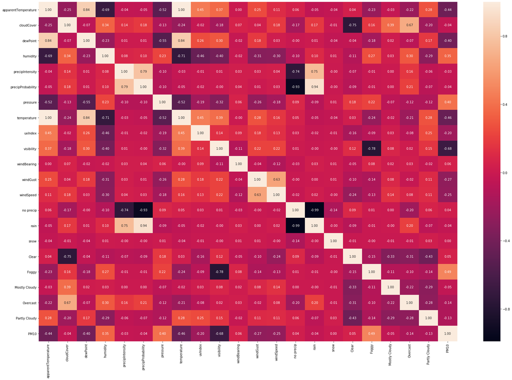

```python
#Correlation Matrix that includes the Target
result = pd.concat([X, y], axis=1)
correlation_train=result.corr()
plt.figure(figsize=(30, 20))
sns.heatmap(correlation_train, annot=True, fmt='.2f')
plt.show()
```

## Split the data 70%-30%

Set the random_state=1

```python
#split the data, 70% train and 30% test
#from sklearn.model_selection import train_test_split
#X_train, X_test, y_train, y_test = train_test_split(X, y, test_size=0.3, random_state=1)

#this is implement before scaling :)
```

## 3 Default Regressor

Create regressors with default parameters:

- Linear Regression
- LASSO regression
- Random Forest
- SVR
- KNN
- Dummy regressor

Compare the MAE values in a table

```python
from sklearn import linear_model
from sklearn.dummy import DummyRegressor
from sklearn.neighbors import KNeighborsRegressor
from sklearn.ensemble import RandomForestRegressor
from sklearn.svm import SVR
from sklearn.metrics import mean_squared_error, r2_score, mean_absolute_error


# Create linear regression object
lin = linear_model.LinearRegression()
#create Dummy regressor
dummy_regr = DummyRegressor(strategy="mean")
#create Lasso
lasso = linear_model.Lasso()
# create knn
knn = KNeighborsRegressor(n_neighbors=5)
# create SVR
svr = SVR(kernel = 'rbf',C=100, epsilon=0.9)
#create RF
rf = RandomForestRegressor(random_state=1)

# Train the models
lin.fit(X_train, y_train)
dummy_regr.fit(X_train, y_train)
lasso.fit(X_train, y_train)
knn.fit(X_train, y_train)
svr.fit(X_train, y_train)
rf.fit(X_train, y_train)

# Make predictions using the testing set
y_pred = lin.predict(X_test)
y_dummy = dummy_regr.predict(X_test)
y_lasso = lasso.predict(X_test)
y_knn = knn.predict(X_test)
y_svr = svr.predict(X_test)
y_rf = rf.predict(X_test)

#calculate the metrics
mae = mean_absolute_error(y_test, y_pred)
mse = mean_squared_error(y_test, y_pred)
rmse = np.sqrt(mean_squared_error(y_test, y_pred))
r2 = r2_score(y_test, y_pred)

mae2 = mean_absolute_error(y_test, y_dummy)
mse2 = mean_squared_error(y_test, y_dummy)
rmse2 = np.sqrt(mean_squared_error(y_test, y_dummy))
r22 = r2_score(y_test, y_dummy)

mae3 = mean_absolute_error(y_test, y_lasso)
mse3 = mean_squared_error(y_test, y_lasso)
rmse3 = np.sqrt(mean_squared_error(y_test, y_lasso))
r23 = r2_score(y_test, y_lasso)

mae4 = mean_absolute_error(y_test, y_knn)
mse4 = mean_squared_error(y_test, y_knn)
rmse4 = np.sqrt(mean_squared_error(y_test, y_knn))
r24 = r2_score(y_test, y_knn)

mae5 = mean_absolute_error(y_test, y_svr)
mse5 = mean_squared_error(y_test, y_svr)
rmse5 = np.sqrt(mean_squared_error(y_test, y_svr))
r25 = r2_score(y_test, y_svr)

mae6 = mean_absolute_error(y_test, y_rf)
mse6 = mean_squared_error(y_test, y_rf)
rmse6 = np.sqrt(mean_squared_error(y_test, y_rf))
r26 = r2_score(y_test, y_rf)

#construct the comparison table
data = {'Metric':  ['MAE', 'MSE','RMSE','R2'],
        'Linear Regression': [mae,mse,rmse,r2],
        'Dummy': [mae2,mse2,rmse2,r22],
        'Lasso': [mae3,mse3,rmse3,r23],
        'KNN': [mae4,mse4,rmse4,r24],
        'SVR': [mae5,mse5,rmse5,r25],
        'RF': [mae6,mse6,rmse6,r26]
        }

comparison = pd.DataFrame (data, columns = ['Metric','Linear Regression', 'Dummy','Lasso','KNN','RF'])
comparison
```

|  | Metric | Linear Regression | Dummy | Lasso | KNN | RF |
| --- | --- | --- | --- | --- | --- | --- |
| 0 | MAE | 33.881880 | 54.804403 | 33.822795 | 25.717141 | 21.673362 |
| 1 | MSE | 2751.144164 | 6532.782034 | 2811.436221 | 1960.262523 | 1358.880154 |
| 2 | RMSE | 52.451350 | 80.825627 | 53.022978 | 44.274852 | 36.862992 |
| 3 | R2 | 0.578839 | -0.000075 | 0.569609 | 0.699912 | 0.791975 |

## 3. Feature Selection

Use SelectKBest feature selection technique. Reduce the number of features to 15

Create new regressors with default parameters with the selected 15 features:

- Linear Regression
- LASSO regression
- Random Forest
- SVR
- KNN
- Dummy regressor

Compare the MAE values in a table

```python
from sklearn.feature_selection import SelectKBest, mutual_info_regression
from sklearn.feature_selection import f_regression
from numpy import set_printoptions

# feature selection, top 15 features
test = SelectKBest(score_func= mutual_info_regression, k=15)
fit = test.fit(X_train, y_train)

# summarize scores
#set_printoptions(precision=3)
#print(fit.scores_)
X_new = SelectKBest(score_func= mutual_info_regression, k=15).fit_transform(X_train,y_train)
```

```python
X_new.shape
```

```
(5146, 15)
```

```python
# Create linear regression object
lin = linear_model.LinearRegression()
lin.fit(X_new, y_train)
y_pred_f = lin.predict(fit.transform(X_test))
#create Dummy regressor
dummy_regr = DummyRegressor(strategy="mean")
dummy_regr.fit(X_new, y_train)
y_dummy_f = dummy_regr.predict(fit.transform(X_test))
#RF
rf = RandomForestRegressor(n_estimators= 100, random_state=1)
rf.fit(X_new, y_train)
y_rf_f = lin.predict(fit.transform(X_test))
#lasso
lasso = linear_model.Lasso()
lasso.fit(X_new, y_train)
y_lasso_f =lasso.predict(fit.transform(X_test))
#svr
svr = SVR()
svr.fit(X_new, y_train)
y_svr_f = lasso.predict(fit.transform(X_test))
#knn
knn = KNeighborsRegressor()
knn.fit(X_new, y_train)
y_knn_f = knn.predict(fit.transform(X_test))

#calculate the metrics
mae_fs = mean_absolute_error(y_test, y_pred_f)
mse_fs = mean_squared_error(y_test, y_pred_f)
rmse_fs = np.sqrt(mean_squared_error(y_test, y_pred_f))
r2_fs = r2_score(y_test, y_pred_f)

mae2_fs = mean_absolute_error(y_test, y_dummy_f)
mse2_fs = mean_squared_error(y_test, y_dummy_f)
rmse2_fs = np.sqrt(mean_squared_error(y_test, y_dummy_f))
r22_fs = r2_score(y_test, y_dummy_f)

mae3_fs = mean_absolute_error(y_test, y_lasso_f)
mse3_fs = mean_squared_error(y_test, y_lasso_f)
rmse3_fs = np.sqrt(mean_squared_error(y_test, y_lasso_f))
r23_fs = r2_score(y_test, y_lasso_f)

mae4_fs = mean_absolute_error(y_test, y_knn_f)
mse4_fs = mean_squared_error(y_test, y_knn_f)
rmse4_fs = np.sqrt(mean_squared_error(y_test, y_knn_f))
r24_fs = r2_score(y_test, y_knn_f)

mae5_fs = mean_absolute_error(y_test, y_svr_f)
mse5_fs = mean_squared_error(y_test, y_svr_f)
rmse5_fs = np.sqrt(mean_squared_error(y_test, y_svr_f))
r25_fs = r2_score(y_test, y_svr_f)

mae6_fs = mean_absolute_error(y_test, y_rf_f)
mse6_fs = mean_squared_error(y_test, y_rf_f)
rmse6_fs = np.sqrt(mean_squared_error(y_test, y_rf_f))
r26_fs = r2_score(y_test, y_rf_f)

#construct the comparison table
data = {'Metric':  ['MAE', 'MSE','RMSE','R2'],
        'Linear Regression': [mae_fs,mse_fs,rmse_fs,r2_fs],
        'Dummy': [mae2_fs,mse2_fs,rmse2_fs,r22_fs],
        'Lasso': [mae3_fs,mse3_fs,rmse3_fs,r23_fs],
        'KNN': [mae4_fs,mse4_fs,rmse4_fs,r24_fs],
        'SVR': [mae5_fs,mse5_fs,rmse5_fs,r25_fs],
        'RF': [mae6_fs,mse6_fs,rmse6_fs,r26_fs]
        }

comparison = pd.DataFrame (data, columns = ['Metric','Linear Regression', 'Dummy','Lasso','KNN','RF'])
comparison
```

|  | Metric | Linear Regression | Dummy | Lasso | KNN | RF |
| --- | --- | --- | --- | --- | --- | --- |
| 0 | MAE | 39.866301 | 54.804403 | 34.894876 | 32.330917 | 39.866301 |
| 1 | MSE | 3157.581706 | 6532.782034 | 2985.463694 | 2900.395738 | 3157.581706 |
| 2 | RMSE | 56.192363 | 80.825627 | 54.639397 | 53.855322 | 56.192363 |
| 3 | R2 | 0.516620 | -0.000075 | 0.542968 | 0.555991 | 0.516620 |

Compare the the two tables (all features vs top15 features). Discuss the results

```python
#construct the comparison table
data = {'Metric':  ['MAE', 'MAE_FS'],
        'Linear Regression': [mae,mae_fs],
        'Dummy': [mae2, mae2_fs],
        'Lasso': [mae3, mae3_fs],
        'KNN': [mae4, mae4_fs],
        'SVR': [mae5, mae5_fs],
        'RF': [mae6, mae6_fs]
        }

comparison = pd.DataFrame (data, columns = ['Metric','Linear Regression', 'Dummy','Lasso','KNN','RF'])
comparison
```

|  | Metric | Linear Regression | Dummy | Lasso | KNN | RF |
| --- | --- | --- | --- | --- | --- | --- |
| 0 | MAE | 33.881880 | 54.804403 | 33.822795 | 25.717141 | 21.673362 |
| 1 | MAE_FS | 39.866301 | 54.804403 | 34.894876 | 32.330917 | 39.866301 |

The prediction with 15 features have bigger mae.

## 4. Hyperparameter Optimization

Use the dataset with the selected 15 features.

### 4.1 Random Search

Use Random Search CV to optimize the parameters for:

- LASSO regression
- Random Forest
- SVR

Use appropriate n_iter, so that it ends in a reasonable time  
Use CV = 3

Use Cross Validation for optimization, and the test set for final evaluation  
**DO NOT OPTIMIZE ON THE TEST SET**

- on the CV
- on the test set

```python
# We will use Cross validation to optimize parameters
import warnings
warnings.filterwarnings('ignore')

from sklearn.model_selection import cross_val_predict
from sklearn.model_selection import cross_validate
np.random.seed(seed=1)
from sklearn.model_selection import KFold
kf = KFold(n_splits=10, shuffle=True)
#10-fold Cross validaiton - ALL Model - All scores
scoring = ['neg_mean_absolute_error', 'neg_mean_squared_error', 'neg_root_mean_squared_error', 'r2']


# Number of trees in random forest
n_estimators = [int(x) for x in np.linspace(start = 200, stop = 2000, num = 10)]
# Number of features to consider at every split
max_features = ['auto', 'sqrt']
# Maximum number of levels in tree
max_depth = [int(x) for x in np.linspace(10, 110, num = 11)]
max_depth.append(None)
# Minimum number of samples required to split a node
min_samples_split = [2, 5, 15]
# Minimum number of samples required at each leaf node
min_samples_leaf = [1, 2, 4]
# Method of selecting samples for training each tree
bootstrap = [True, False]

from sklearn.model_selection import RandomizedSearchCV
# Create the random grid
random_search = {'n_estimators': n_estimators,
               'max_features': max_features,
               'max_depth': max_depth,
               'min_samples_split': min_samples_split,
               'min_samples_leaf': min_samples_leaf,
               'bootstrap': bootstrap}

clf = RandomForestRegressor(random_state=42)
model = RandomizedSearchCV(estimator = clf, param_distributions = random_search, n_iter = 50,
                               cv = 3, verbose= 5, random_state= 1, n_jobs = -1)

model.fit(X_new,y_train)
```

```
Fitting 3 folds for each of 50 candidates, totalling 150 fits
```

```
[Parallel(n_jobs=-1)]: Using backend LokyBackend with 4 concurrent workers.
[Parallel(n_jobs=-1)]: Done  10 tasks      | elapsed:  1.2min
[Parallel(n_jobs=-1)]: Done  64 tasks      | elapsed:  7.8min
[Parallel(n_jobs=-1)]: Done 150 out of 150 | elapsed: 16.2min finished
```

```
RandomizedSearchCV(cv=3, error_score=nan,
                   estimator=RandomForestRegressor(bootstrap=True,
                                                   ccp_alpha=0.0,
                                                   criterion='mse',
                                                   max_depth=None,
                                                   max_features='auto',
                                                   max_leaf_nodes=None,
                                                   max_samples=None,
                                                   min_impurity_decrease=0.0,
                                                   min_impurity_split=None,
                                                   min_samples_leaf=1,
                                                   min_samples_split=2,
                                                   min_weight_fraction_leaf=0.0,
                                                   n_estimators=100,
                                                   n_jobs=None, oob_score=Fals...
                   iid='deprecated', n_iter=50, n_jobs=-1,
                   param_distributions={'bootstrap': [True, False],
                                        'max_depth': [10, 20, 30, 40, 50, 60,
                                                      70, 80, 90, 100, 110,
                                                      None],
                                        'max_features': ['auto', 'sqrt'],
                                        'min_samples_leaf': [1, 2, 4],
                                        'min_samples_split': [2, 5, 15],
                                        'n_estimators': [200, 400, 600, 800,
                                                         1000, 1200, 1400, 1600,
                                                         1800, 2000]},
                   pre_dispatch='2*n_jobs', random_state=1, refit=True,
                   return_train_score=False, scoring=None, verbose=5)
```

```python
y_rf_hp = model.best_estimator_.predict(fit.transform(X_test))
```

```python
#Lasso
alphas = np.array([5, 0.5, 0.05, 0.005, 0.0005, 1, 0.1, 0.01, 0.001, 0.0001, 0])
fit_intercept = [True,False]
normalize = [True,False]
precompute = [True, False]
max_iter = [int(x) for x in np.linspace(start = 100, stop = 1000, num = 50)]
random_search = {'alpha': alphas,
               'fit_intercept': fit_intercept,
               'normalize': normalize,
               'precompute': precompute,
               'max_iter': max_iter,
               }

clf = linear_model.Lasso()
model = RandomizedSearchCV(estimator = clf, param_distributions = random_search, n_iter = 50,
                               cv = 3, verbose= 5, random_state= 1, n_jobs = -1)

model.fit(X_new,y_train)
```

```
Fitting 3 folds for each of 50 candidates, totalling 150 fits
```

```
[Parallel(n_jobs=-1)]: Using backend LokyBackend with 4 concurrent workers.
[Parallel(n_jobs=-1)]: Done  24 tasks      | elapsed:    0.5s
[Parallel(n_jobs=-1)]: Done 112 out of 150 | elapsed:    1.1s remaining:    0.3s
[Parallel(n_jobs=-1)]: Done 150 out of 150 | elapsed:    1.5s finished
```

```
RandomizedSearchCV(cv=3, error_score=nan,
                   estimator=Lasso(alpha=1.0, copy_X=True, fit_intercept=True,
                                   max_iter=1000, normalize=False,
                                   positive=False, precompute=False,
                                   random_state=None, selection='cyclic',
                                   tol=0.0001, warm_start=False),
                   iid='deprecated', n_iter=50, n_jobs=-1,
                   param_distributions={'alpha': array([5.e+00, 5.e-01, 5.e-02, 5.e-03, 5.e-04, 1.e+00, 1.e-01, 1.e-02,
       1.e-03, 1.e-04, 0.e+00]),
                                        'fit_intercept': [True, False],
                                        'max_iter': [100, 118, 136, 155, 173,
                                                     191, 210, 228, 246, 265,
                                                     283, 302, 320, 338, 357,
                                                     375, 393, 412, 430, 448,
                                                     467, 485, 504, 522, 540,
                                                     559, 577, 595, 614, 632, ...],
                                        'normalize': [True, False],
                                        'precompute': [True, False]},
                   pre_dispatch='2*n_jobs', random_state=1, refit=True,
                   return_train_score=False, scoring=None, verbose=5)
```

```python
y_lasso_hp = model.best_estimator_.predict(fit.transform(X_test))
#############

lasso_reg = linear_model.Lasso(alpha=1.0,
                              fit_intercept=True,
                              normalize=False,
                              precompute=False,
                              max_iter=50,
                              warm_start=True,
                              random_state=1)

scores1 = cross_validate(lasso_reg, X_new, y_train, cv=kf,scoring=scoring_list)
y_pred_lasso = cross_val_predict(lasso_reg, X_new, y_train,cv=kf)
```

```python
#parametar
kernel = ['linear', 'poly', 'rbf', 'sigmoid']
gamma = ['scale', 'auto']
C = range(1,100)
max_iter = [int(x) for x in np.linspace(start = 100, stop = 1000, num = 50)]
epsilon = [float(x) for x in np.linspace(start = 100, stop = 1000, num = 50)]
random_search = {'kernel': kernel,
               'epsilon': epsilon,
               'max_iter': max_iter,
                 'gamma': gamma,
                 'C':C
               }

clf = SVR()
model = RandomizedSearchCV(estimator = clf, param_distributions = random_search, n_iter = 100,
                               cv = 3, verbose= 5, random_state= 1, n_jobs = -1)

model.fit(X_new,y_train)
```

```
Fitting 3 folds for each of 100 candidates, totalling 300 fits
```

```
[Parallel(n_jobs=-1)]: Using backend LokyBackend with 4 concurrent workers.
[Parallel(n_jobs=-1)]: Done  40 tasks      | elapsed:    0.3s
[Parallel(n_jobs=-1)]: Done 232 out of 300 | elapsed:    2.1s remaining:    0.5s
[Parallel(n_jobs=-1)]: Done 300 out of 300 | elapsed:    4.6s finished
```

```
RandomizedSearchCV(cv=3, error_score=nan,
                   estimator=SVR(C=1.0, cache_size=200, coef0=0.0, degree=3,
                                 epsilon=0.1, gamma='scale', kernel='rbf',
                                 max_iter=-1, shrinking=True, tol=0.001,
                                 verbose=False),
                   iid='deprecated', n_iter=100, n_jobs=-1,
                   param_distributions={'C': range(1, 100),
                                        'epsilon': [100.0, 118.36734693877551,
                                                    136.73469387755102,
                                                    155.10204081632654,
                                                    173.46938775510...
                                                    595.9183673469388,
                                                    614.2857142857143,
                                                    632.6530612244899, ...],
                                        'gamma': ['scale', 'auto'],
                                        'kernel': ['linear', 'poly', 'rbf',
                                                   'sigmoid'],
                                        'max_iter': [100, 118, 136, 155, 173,
                                                     191, 210, 228, 246, 265,
                                                     283, 302, 320, 338, 357,
                                                     375, 393, 412, 430, 448,
                                                     467, 485, 504, 522, 540,
                                                     559, 577, 595, 614, 632, ...]},
                   pre_dispatch='2*n_jobs', random_state=1, refit=True,
                   return_train_score=False, scoring=None, verbose=5)
```

```python
y_svr_hp = model.best_estimator_.predict(fit.transform(X_test))

#######
svr_cv = SVR()
scores1 = cross_validate(svr_cv, X_new, y_train, cv=kf,scoring=scoring_list)
y_pred_svr = cross_val_predict(svr_cv, X_new, y_train,cv=kf)
```

```python
mae_rf = mean_absolute_error(y_test, y_rf_hp)
mae_lasso = mean_absolute_error(y_test, y_lasso_hp)
mae_svr = mean_absolute_error(y_test, y_svr_hp)
```

```python
#construct the comparison table
data = {'Metric':  ['MAE', 'MAE_HP'],
        'Lasso': [mae3, mae_lasso],
        'SVR': [mae5, mae_svr],
        'RF': [mae6, mae_rf]
        }

comparison = pd.DataFrame (data, columns = ['Metric','Lasso','SVR','RF'])
comparison
```

|  | Metric | Lasso | SVR | RF |
| --- | --- | --- | --- | --- |
| 0 | MAE | 33.822795 | 26.169933 | 21.673362 |
| 1 | MAE_HP | 39.847561 | 78.223075 | 24.139230 |

## 5. SUMMARY

Visualize the errors (actual vs predicted)

```
[Text(0, 0.5, 'Predicted'), Text(0.5, 0, 'Actual')]
```

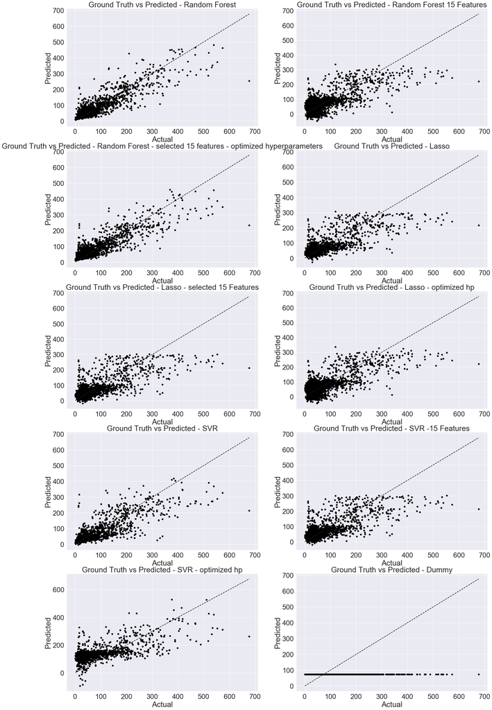

```python
sns.set(font_scale=2.5)
fig, ((ax1, ax2), (ax3, ax4), (ax5, ax6), (ax7, ax8), (ax9, ax10)) = plt.subplots(5, 2, figsize=(30,50))

ax1.scatter(y_test, y_rf, color='black')
ax1.plot([y_test.min(), y_test.max()], [y_test.min(), y_test.max()], 'k--', lw=2)
ax1.set_title('Ground Truth vs Predicted - Random Forest')
ax1.set(xlabel='Actual', ylabel='Predicted')

ax2.scatter(y_test, y_rf_f, color='black')
ax2.plot([y_test.min(), y_test.max()], [y_test.min(), y_test.max()], 'k--', lw=2)
ax2.set_title('Ground Truth vs Predicted - Random Forest 15 Features')
ax2.set(xlabel='Actual', ylabel='Predicted')

ax3.scatter(y_test, y_rf_hp, color='black')
ax3.plot([y_test.min(), y_test.max()], [y_test.min(), y_test.max()], 'k--', lw=2)
ax3.set_title('Ground Truth vs Predicted - Random Forest - selected 15 features - optimized hyperparameters')
ax3.set(xlabel='Actual', ylabel='Predicted')

ax4.scatter(y_test, y_lasso, color='black')
ax4.plot([y_test.min(), y_test.max()], [y_test.min(), y_test.max()], 'k--', lw=2)
ax4.set_title('Ground Truth vs Predicted - Lasso')
ax4.set(xlabel='Actual', ylabel='Predicted')

ax5.scatter(y_test, y_lasso_f, color='black')
ax5.plot([y_test.min(), y_test.max()], [y_test.min(), y_test.max()], 'k--', lw=2)
ax5.set_title('Ground Truth vs Predicted - Lasso - selected 15 Features')
ax5.set(xlabel='Actual', ylabel='Predicted')

ax6.scatter(y_test, y_lasso_hp, color='black')
ax6.plot([y_test.min(), y_test.max()], [y_test.min(), y_test.max()], 'k--', lw=2)
ax6.set_title('Ground Truth vs Predicted - Lasso - optimized hp')
ax6.set(xlabel='Actual', ylabel='Predicted')

ax7.scatter(y_test, y_svr, color='black')
ax7.plot([y_test.min(), y_test.max()], [y_test.min(), y_test.max()], 'k--', lw=2)
ax7.set_title('Ground Truth vs Predicted - SVR')
ax7.set(xlabel='Actual', ylabel='Predicted')

ax8.scatter(y_test, y_svr_f, color='black')
ax8.plot([y_test.min(), y_test.max()], [y_test.min(), y_test.max()], 'k--', lw=2)
ax8.set_title('Ground Truth vs Predicted - SVR -15 Features')
ax8.set(xlabel='Actual', ylabel='Predicted')

ax9.scatter(y_test, y_svr_hp, color='black')
ax9.plot([y_test.min(), y_test.max()], [y_test.min(), y_test.max()], 'k--', lw=2)
ax9.set_title('Ground Truth vs Predicted - SVR - optimized hp')
ax9.set(xlabel='Actual', ylabel='Predicted')

ax10.scatter(y_test, y_dummy, color='black')
ax10.plot([y_test.min(), y_test.max()], [y_test.min(), y_test.max()], 'k--', lw=2)
ax10.set_title('Ground Truth vs Predicted - Dummy')
ax10.set(xlabel='Actual', ylabel='Predicted')
```

Summarize the results (MAE) for the following models in a single table:

- Random Forest - default parameters
- Random Forest - selected 15 features
- Random Forest - selected 15 features - optimized hyperparameters
- LASSO - default parameters
- LASSO - selected 15 features
- LASSO - selected 15 features - optimized hyperparameters
- SVR - default parameters
- SVR - selected 15 features
- SVR - selected 15 features - optimized hyperparameters
- Dummy regressor

```python
data = {'Metric':  ['MAE'],
        'RF':[mae6],
        'RF -15':[mae6_fs],
        'RF -HP':[mae_rf],
        'Lasso': [mae3],
        'Lasso-15':[mae3_fs],
        'Lasso-HP':[mae_lasso],
        'SVR': [mae5],
        'SVR-15':[mae5_fs],
        'SVR-HP':[mae_svr],
        'Dummy': [mae2]
        }

comparison = pd.DataFrame (data, columns = ['Metric','RF','RF -15','RF -HP','Lasso','Lasso-15','Lasso-HP','SVR','SVR-15','SVR-HP','Dummy'])
comparison
```

[output not shown]